# Prepare Files for Simulations

Author

NAMLink

# Set up

```r
rm(list=ls())

library(tidyverse)
library(readxl)
library(openxlsx)
library(purrr)
library(esqlabsR)
```

# Observed Data

- We digitized monkey and human PK data for various anti-PD1 monoclonal antibodies:
  - https://jpharmsci.org/article/S0022-3549(24)00249-1/abstract
- See template.xlsx in RawData folder - this specific template needed for reading data into simulations by esqlabsr package
- For this run, the data has already been set-up in the required format
- The formatted data are : Data/mAb_data_1.csv

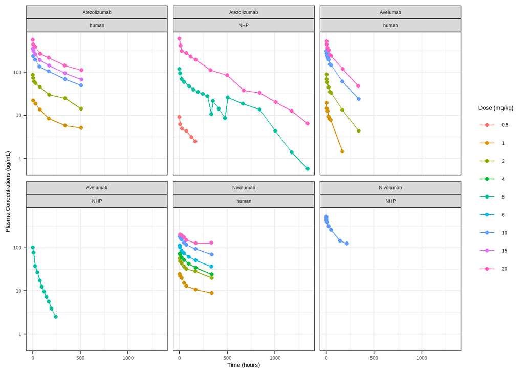

```r
### extracted data path
datadir <- "../Data/"

# Read observed data
dat <- read.csv(file=file.path(datadir, "mAb_data_1.csv"), stringsAsFactors = F, check.names = FALSE)

# Review data
ggplot(dat, aes(x=Time, y=Measurement,
                color=factor(Dose))) +
  geom_point() +
  geom_line() +
  facet_wrap(~Molecule+Species) +
  scale_y_log10() +
  labs(color="Dose (mg/kg)", y="Plasma Concentrations (ug/mL)", x="Time (hours)") +
  theme_bw()
```

# Define drug-specific parameters

| Parameter | Symbol | Unit | Source |
| --- | --- | --- | --- |
| Molecular weight | MW | g/mol | Observed data (`Molecular Weight` column) |
| FcRn binding affinity | Kd (FcRn) | µmol/l | Literature / measured |
| Target (PD-1) binding affinity | Kd | nmol/l | Literature / measured |
| Target dissociation rate | koff | 1/s | Literature / measured |

```r
# ── INPUT: molecule-specific binding parameters ───────────────────────────
# When we make app, these parameters need to be set-up by user per molecule up front
# One row per molecule. MW is pulled from the observed data automatically.
# Add or remove rows here as new molecules are included in the dataset.
mol_pk_input <- tribble(
  ~Molecule,        ~kd_fcrn,  ~kd_target,  ~koff,
  #                  µmol/l     nmol/l        1/s
  "Atezolizumab",   0.65,      2.6,          1.56e-4,
  "Avelumab",       1.30,      0.0467,       7.53e-5,
  "Nivolumab",      0.15,      2.6,          7.70e-4
)
```

# Configure PBPK simulations

## Initiate a simulations project

```r
### Initiate an esqlabsr project (run first time for project setup only)
#### esqlabsR::initProject(destination = "../")

### configurations path
confdir <- "../Configurations"

## Read helper functions
source("00_functions.R")
```

# Manual files set-up in Configurations folder

- We want to use generic anti PD-1 monoclonal antibody PBPK model that has been previously set-up and exported. It has been saved in the Models/Simulations folder.
- We copied already set-up PopulationsCSV, Populations.xlsx, and Individuals.xlsx files in Configurations folder from our prior projects. These files don’t need to be updated unless we want other species simulations or change population characteristics. For now, we keep them as it is.

# Code-based files set-up in Configurations folder based on data

## Model Parameters

`ModelParameters.xlsx` contains one sheet per **Molecule_Species** combination (e.g. `Atezolizumab_Human`, `Nivolumab_Monkey`) plus a `Global` sheet. Each sheet lists the PK-Sim parameter container paths, names, values, and units that override the defaults in the loaded simulation. The workbook is read by esqlabsR at runtime to parameterise each scenario.

The container paths for all parameters are resolved automatically from the loaded `.pkml` simulation file, keeping this code valid even if the model is rebuilt or expanded with additional organ compartments.

```r
# ── Load simulation once to resolve parameter container paths ─────────────
sim <- loadSimulation("../Models/Simulations/PD-1_mAb_wTMDD.pkml")


# MW auto-merged from observed data — no manual entry needed
mw_lookup <- dat %>%
  distinct(Molecule, `Molecular Weight`) %>%
  rename(mw = `Molecular Weight`)

mol_input <- left_join(mol_pk_input, mw_lookup, by = "Molecule")

# Species labels derived from observed data and normalised for sheet naming
species_list <- dat %>%
  distinct(Species) %>%
  mutate(Species = normalize_species(Species)) %>%
  pull(Species)

# Write Configurations/ModelParameters.xlsx
write_model_params_xlsx(
  mol_input = mol_input,
  sim       = sim,
  species   = species_list,
  out_path  = file.path(confdir, "ModelParameters.xlsx")
)
```

## Applications

`Applications.xlsx` defines the dosing protocol for every simulation scenario. esqlabsR expects **one sheet per scenario**, with the sheet name matching the `ScenarioName` column in `Scenarios.xlsx`. The convention used here is `{Molecule}_{Species}_{Dose}_mpk` (e.g. `Atezolizumab_Human_10_mpk`).

Each sheet maps directly to the IV application event in the `.pkml` model and contains a single row with these columns:

| Column | Description |
| --- | --- |
| `Container Path` | Path to the application event in PK-Sim (must match `.pkml`) |
| `Parameter Name` | `DosePerBodyWeight` |
| `Value` | Dose in mg/kg |
| `Units` | `mg/kg` |
| `Infusion time` | Duration parsed automatically from the `Route` label |
| `Infusion time unit` | `min` |

The infusion duration is extracted automatically from the `Route` field: `"IV 1hr Infusion"` → 60 min, `"IV 0.5hr Infusion"` → 30 min, `"IV Bolus"` → 1 min (short-infusion approximation used by PK-Sim). All Molecule × Species × Dose combinations present in the data are written — no manual scenario list is needed.

```r
# ── INPUT: PK-Sim application event container path ────────────────────────
# This must match the event name in the loaded .pkml model exactly.
# Update if the model is rebuilt with a different application event name.
app_container_path <- "Events|Single_IV_Infusion|Application_1|ProtocolSchemaItem"

# Write Configurations/Applications.xlsx
write_applications_xlsx(
  dat            = dat,
  out_path       = file.path(confdir, "Applications.xlsx"),
  container_path = app_container_path,
  bolus_min      = 1     # infusion time (min) used for "IV Bolus" routes
)
```

## Scenarios

`Scenarios.xlsx` is the master run-list that esqlabsR reads to execute bulk simulations. It contains two sheets:

- **`Scenarios`** — one row per simulation (Molecule × Species × Dose). Each row wires together the model file, population, molecule parameters, and dosing protocol for that specific run.
- **`OutputPaths`** — maps short IDs (e.g. `Atezolizumab_PVB`) to the full PK-Sim output path for each molecule’s peripheral venous blood plasma concentration. These IDs are referenced in the `OutputPathsIds` column of the `Scenarios` sheet.

All scenarios use a fixed simulation window of 28 days (672 h). The `SimulationTime` field written to `Scenarios.xlsx` follows the esqlabsR format `"start, end, resolution;"` — here `"0, 672, 1;"` meaning simulate from 0 to 672 h with output saved every 1 h.

```r
# ── INPUT: population IDs (must match names defined in Populations.xlsx) ──
population_map <- c(
  Human  = "Human",
  Monkey = "Monkey"
)

# ── INPUT: molecule name as it appears inside the .pkml model ─────────────
# Open the model in PK-Sim / Mobi and check the molecule entity name in the
# model tree. For this generic mAb PBPK model the biologic is named "mAb".
# Update this string if you rebuild the model with a different entity name.
model_mol_name <- "mAb"

# Write Configurations/Scenarios.xlsx
write_scenarios_xlsx(
  dat            = dat,
  model_file     = "PD-1_mAb_wTMDD.pkml",
  out_path       = file.path(confdir, "Scenarios.xlsx"),
  population_map = population_map,
  model_mol_name = model_mol_name,
  sim_end_h      = 28 * 24,  # 672 h — simulate full 28 days
  time_res       = 1          # output step size (h): 1 = save every hour
)
```